# [R Lab 2: Functions, Optimization, and Simulation Part 1](http://htmlpreview.github.io/?http://raw.githubusercontent.com/justingrimmer/MathCamp/master/Labs/Lab_2/Lab_2___Functions1.html)

University of Chicago Computational Math Camp, 2017

TAs: Joshua Mausolf and Ryan Hughes

(with material from previous TAs: Hans Lueders, Jonathan Mummolo, and Erik Peterson)

Thursday, August 31, 2017

# 1. Functions in R

### Introduction

Simply put, functions take an input and produce an output. There are many examples in R. Some help with reading in data (e.g., read.csv()), others help with manipulating data (e.g., subset()), or estimating statsitical models (e.g., lm())

Some functions are part of base R (the set of functions that come with R when you install the program) and can be called immediately on starting it up. However others must be installed and called as part of a package.

Once you’ve found a package and loaded the function someone else wrote (or have identified a function in base R that you want to learn more about), you can examine the contents of a package or function for content by placing the function’s name after a question mark or the package name after two question marks:

```r
?read.csv
?subset
?lm
```

However, there will also be instances in which a canned function does not exist for what you want to do. You may have some repetitive task you need to perform over and over throughout a data analysis. Rather than clutter up your code by copy and pasting a single operation multiple times, you can write a function that does the task and use it throughout your code. Another advantage is that this also reduces the chances for user error in copying several lines of code.

So let’s write a function in the truest sense. One that takes a numeric vector as an input, performs an operation and outputs a numeric vector with the results.

Throughout this session (and the quarter) we’re going to talk a lot about quadratic functions like the following: $y = -(x-1)^2 + 8$.

Although basic, these sorts of functions are used to underpin sophisticated analyses of voting behavior, among many other things. Quadratic loss functions are also central to Ordinary Least Squares Regression which you will learn more about in 450A.

### Writing a Function in R

To write a function in R, you first need to specify the inputs. Depending on your task, these might be data frames or a single number or a string of text. In this case, our function will take a numeric vector we call “input.values”. Of course, functions can also take various inputs (even of different classes). But we will keep it simple for now.

Once inside the braces you specify the operation the function should perform on these inputs. We want to produce a numeric vector that performs a set operation on each numeric item it receives.

Finally, using return() you need to specify what the function will put back into the broader R environment.

```r
quadratic.function <- function(input.values){
    y.values <- -(input.values-1)^2 + 8
    return(y.values)
}
```

Let’s try our function out with the sequence of numbers below:

```r
domain.1 <- seq(from=-2, to=2, by=0.1)
domain.1
```

```
##  [1] -2.0 -1.9 -1.8 -1.7 -1.6 -1.5 -1.4 -1.3 -1.2 -1.1 -1.0 -0.9 -0.8 -0.7
## [15] -0.6 -0.5 -0.4 -0.3 -0.2 -0.1  0.0  0.1  0.2  0.3  0.4  0.5  0.6  0.7
## [29]  0.8  0.9  1.0  1.1  1.2  1.3  1.4  1.5  1.6  1.7  1.8  1.9  2.0
```

To call the function, you write its name and then place the inputs inside parentheses:

```r
quadratic.function(domain.1)
```

```
##  [1] -1.00 -0.41  0.16  0.71  1.24  1.75  2.24  2.71  3.16  3.59  4.00
## [12]  4.39  4.76  5.11  5.44  5.75  6.04  6.31  6.56  6.79  7.00  7.19
## [23]  7.36  7.51  7.64  7.75  7.84  7.91  7.96  7.99  8.00  7.99  7.96
## [34]  7.91  7.84  7.75  7.64  7.51  7.36  7.19  7.00
```

If you don’t provide an object to receive the output, it will display on the screen like above. However, you can also pass the function output to an object like this:

```r
quadratic.outputs <- quadratic.function(domain.1)
quadratic.outputs
```

```
##  [1] -1.00 -0.41  0.16  0.71  1.24  1.75  2.24  2.71  3.16  3.59  4.00
## [12]  4.39  4.76  5.11  5.44  5.75  6.04  6.31  6.56  6.79  7.00  7.19
## [23]  7.36  7.51  7.64  7.75  7.84  7.91  7.96  7.99  8.00  7.99  7.96
## [34]  7.91  7.84  7.75  7.64  7.51  7.36  7.19  7.00
```

What a great function! Let’s take a few moments and figure out some ways to break it or make the function hard to use:

- not numeric inputs

```r
false.input1 <- c("Hello", "World")
quadratic.function(false.input1)
```

```
## Error in input.values - 1: non-numeric argument to binary operator
```

- both numeric and non-numeric inputs

```r
false.input2 <- c(c(1,2,3), c("Hello", "World"))
quadratic.function(false.input2)
```

```
## Error in input.values - 1: non-numeric argument to binary operator
```

- input containing missing values—this works! But it depicts “NA” for the missing element.

```r
false.input3 <- c(1,2,NA,4,5)
quadratic.function(false.input3)
```

```
## [1]  8  7 NA -1 -8
```

### If-else and conditional statements in R

OK, time for a sequel that dramatically improves on the first version. Let’s write an updated function that more politely informs the user of one reason it may not work. Specifically, we want the function to tell us if the input is not numeric (a string, for example)

```r
## Coding new function
quadratic.function2 <- function(input.values){
    if(is.numeric(input.values)){
      y.values <- -(input.values-1)^2 + 8
      return(y.values)
    }
    else{
      return("Error: Only Input Numeric Objects Please!")
    }
}

## Applying new function
quadratic.function("a")
```

```
## Error in input.values - 1: non-numeric argument to binary operator
```

```r
quadratic.function2("a")
```

```
## [1] "Error: Only Input Numeric Objects Please!"
```

You’ll note that the work this updated function does is based on an “if-else” statement. These are conditional statements which are incredibly useful in writing functions and constructing variables. The basic structure is as follows. **First** you specify some sort of logic condition that may or may not be met. In the above case, the condition is whether our function receieved a numeric vector from the outside environment.

```r
is.numeric(2)
```

```
## [1] TRUE
```

```r
is.numeric("2")
```

```
## [1] FALSE
```

In the above examples you can see that “is.numeric()” produces a “TRUE” value if passed a numeric vector and a “FALSE” if this is not the case. To make an if-else statement work you’ll need to specificy a condition that produces logic statements like this.

**Second**, if the statement is evaluated as true, then the operation in the braces immediately following the statement is performed. However, if the statement evaluates as false, then the action taken comes from the “else” portion of the statement. In the above example this means we get an error message when passing a non-numeric vector to the function.

R has a variety of logic statements that can be used in if-else statements or any other setting where you need to employ a TRUE/FALSE logic, here are a few of the most useful:

- “==” tests the equality of two objects

```r
2==2
```

```
## [1] TRUE
```

```r
2=="A"
```

```
## [1] FALSE
```

- “!=” test whether two objects are NOT equal

```r
2 != 2
```

```
## [1] FALSE
```

```r
2 != "A"
```

```
## [1] TRUE
```

- “>”, “<”, “<=”, “>=” test greater than / less than for two objects

```r
3 > 2
```

```
## [1] TRUE
```

```r
4 >= 4
```

```
## [1] TRUE
```

```r
4 <= 4
```

```
## [1] TRUE
```

- Sometimes logic statements might have multiple parts, “&” lets you chain together multiple conditions that must be simultaneously satisfied to be evaluated as true

```r
number <- 5
number !=3 & number > 1
```

```
## [1] TRUE
```

```r
number <- 1
number !=3 & number > 1
```

```
## [1] FALSE
```

- You can also use “|” to specify an “or” condition. This means the overall statement evaluates as “TRUE” if any single component of the logic chain is satisfied

```r
number <- 10

number == "A"
```

```
## [1] FALSE
```

```r
number > 8
```

```
## [1] TRUE
```

```r
number == "A" | number > 8
```

```
## [1] TRUE
```

A very useful command is the “ifelse()” function. Depending on whether an element of its input vector is TRUE or FALSE as defined by a condition included in the function, it returns either of two values. For example, say we have a vector of the first ten natural numbers. We want to create a corresponding vector of a dichotomous variable that is “0” for odd and “1” for even numbers:

```r
## generate vector of natural numbers
nat.numbers <- seq(1,10,1)

## first element of ifelse command: TRUE/FALSE condition; second element: value if condition is TRUE; third element: value if condition is FALSE.
odd.even <- ifelse(nat.numbers %% 2 == 1, 0, 1)
rbind(nat.numbers, odd.even)
```

```
##             [,1] [,2] [,3] [,4] [,5] [,6] [,7] [,8] [,9] [,10]
## nat.numbers    1    2    3    4    5    6    7    8    9    10
## odd.even       0    1    0    1    0    1    0    1    0     1
```

“Ifelse()” can also return non-numerical values:

```r
odd.even2 <- ifelse(nat.numbers %% 2 == 1, "odd", "even")
rbind(nat.numbers, odd.even2)
```

```
##             [,1]  [,2]   [,3]  [,4]   [,5]  [,6]   [,7]  [,8]   [,9]
## nat.numbers "1"   "2"    "3"   "4"    "5"   "6"    "7"   "8"    "9"
## odd.even2   "odd" "even" "odd" "even" "odd" "even" "odd" "even" "odd"
##             [,10]
## nat.numbers "10"
## odd.even2   "even"
```

We can also include ifelse-statements in ifelse-statements. For example, say we want to first code whether an element from the nat.numbers vector can be divided by 3. If that is not the case, we want to classify each element as odd or even:

```r
odd.even3 <- ifelse(nat.numbers %% 3==0, "Yes",
                    ifelse(nat.numbers%% 2 == 1, "odd", "even"))
rbind(nat.numbers, odd.even3)
```

```
##             [,1]  [,2]   [,3]  [,4]   [,5]  [,6]  [,7]  [,8]   [,9]
## nat.numbers "1"   "2"    "3"   "4"    "5"   "6"   "7"   "8"    "9"
## odd.even3   "odd" "even" "Yes" "even" "odd" "Yes" "odd" "even" "Yes"
##             [,10]
## nat.numbers "10"
## odd.even3   "even"
```

### Exercises

#### Fixing code

The following function doesn’t produce any output. What went wrong?

```r
broken.function <- function(number){
                    if(inputs==5){
                        return("FIVE")
                    }
                    }

broken.function(8)
```

```
## Error in broken.function(8): object 'inputs' not found
```

What went wrong here?

```r
inputs <- seq(1,30,1)

# broken.function2 <- function(inputs){
#  inputs.new <- ifelse(inputs %% 2=0, 1)
#  return(inputs.new)
#}

broken.function2(inputs)
```

```
## Error in eval(expr, envir, enclos): could not find function "broken.function2"
```

#### Creating your own function

Create a function that takes a vector as input. If the sum of all elements of this vector is less than or equal to 100, it returns the sum of all elements that can be divided by five without remainder. If the sum of all elements exceeds 100, it returns the mean of all elements. Apply your function to two vectors: (1) the first ten natural numbers; (2) the first 100 natural numbers.

# 2. An Introduction to Optimization in R

### Spatial Models of Politics

Now let’s talk about optimization in R. But first, a brief aside about spatial models of politics. Building off of work in economics by Hotelling (1929), Black (1948) (and later Downs (1957)) formalized a spatial model of politics. In simple spatial models, politics is conceived as a single dimension running from left (extremely liberal) to right (extremely conservative). Policy proposals, legislators and voters all occupy places on this political dimension. The action of politics is structured by where these actors are placed. Each actor’s utility from a policy proposal depends on the distance between her ideal point and the position of the proposal in the political space.

Let’s assume our humble quadratic function from before actually represents the utility of a single legislator considering a variety of policy alternatives

Here’s a plot of what this function looks like. To make the plot we pass R the x and y values we just generated. There are additional parameters in plot that help with labeling the graph and determining what exactly is plotted. We won’t have time to go through these in great detail today, but there are plenty of plots in this lab that should help you figure out what the different parameters do:

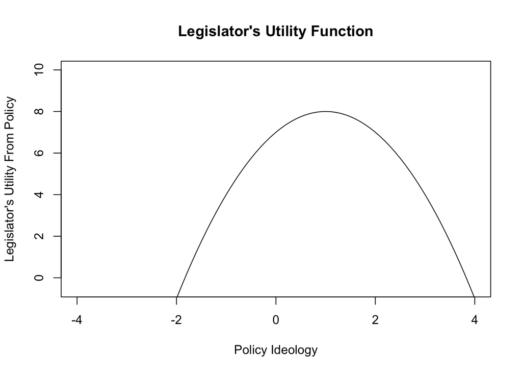

```r
x.values <- seq(from=-2, to=4, by=.1)
y.values <- quadratic.function(seq(from=-2, to=4, by=.1))

plot(x=x.values, y=y.values, type='l', xlab="Policy Ideology",
     ylab="Legislator's Utility From Policy", xlim=c(-4,4),
     ylim=c(-.5,10), main="Legislator's Utility Function")
```